# Homework 6

Dylan Francisco

July 21, 2023

# Instructions

**Exercises:** 4 (Pg. 302); 1 (Pgs. 316-317); 1 (Pgs. 328-329); 1, 2 (Pgs. 353-354)

**Submission:** Submit via an electronic document on Sakai. Must be submitted as a HTML file generated in RStudio. All assigned problems are chosen according to the textbook *R for Data Science*. You do not need R code to answer every question. If you answer without using R code, delete the code chunk. If the question requires R code, make sure you display R code. If the question requires a figure, make sure you display a figure. A lot of the questions can be answered in written response, but require R code and/or figures for understanding and explaining.

# Chapter 16 (Pg. 302)

## Exercise 4

### a)

```r
lastVal = function(x) {
  return (x[[length(x)]])
}
lastVal(1:40)
```

```
## [1] 40
```

### b)

```r
evenElements = function(x) {
  return (x[seq(2, length(x), 2)])

}
evenElements(1:40)
```

```
##  [1]  2  4  6  8 10 12 14 16 18 20 22 24 26 28 30 32 34 36 38 40
```

### c)

```r
removeLast = function(x) {
  return (x[1:length(x) - 1])
}
removeLast(1:10)
```

```
## [1] 1 2 3 4 5 6 7 8 9
```

### d)

```r
evens = function(x) {
  return (x[!is.nan(x) & (x %% 2 ==0)])
}
evens(1:40)
```

```
##  [1]  2  4  6  8 10 12 14 16 18 20 22 24 26 28 30 32 34 36 38 40
```

# Chapter 17 (Pgs. 316-317)

## Exercise 1

### a)

```r
meanColumns = vector("double", ncol(mtcars))
names(meanColumns) = names(mtcars)

for (i in names(mtcars)) {
  meanColumns[[i]] = mean(mtcars[[i]])
}
meanColumns
```

```
##        mpg        cyl       disp         hp       drat         wt       qsec
##  20.090625   6.187500 230.721875 146.687500   3.596563   3.217250  17.848750
##         vs         am       gear       carb
##   0.437500   0.406250   3.687500   2.812500
```

### b)

```r
columnTypes = vector("list", ncol(flights))
names(columnTypes) = names(flights)

for (i in names(flights)){
  columnTypes[[i]] = class(flights[[i]])
}

columnTypes
```

```
## $year
## [1] "integer"
##
## $month
## [1] "integer"
##
## $day
## [1] "integer"
##
## $dep_time
## [1] "integer"
##
## $sched_dep_time
## [1] "integer"
##
## $dep_delay
## [1] "numeric"
##
## $arr_time
## [1] "integer"
##
## $sched_arr_time
## [1] "integer"
##
## $arr_delay
## [1] "numeric"
##
## $carrier
## [1] "character"
##
## $flight
## [1] "integer"
##
## $tailnum
## [1] "character"
##
## $origin
## [1] "character"
##
## $dest
## [1] "character"
##
## $air_time
## [1] "numeric"
##
## $distance
## [1] "numeric"
##
## $hour
## [1] "numeric"
##
## $minute
## [1] "numeric"
##
## $time_hour
## [1] "POSIXct" "POSIXt"
```

### c)

```r
uniqueVals = vector("double", ncol(iris))
names(uniqueVals) = names(iris)

for (i in names(iris)) {
  uniqueVals[[i]] = length(unique(iris[[i]]))
}

uniqueVals
```

```
## Sepal.Length  Sepal.Width Petal.Length  Petal.Width      Species
##           35           23           43           22            3
```

### d)

```r
n = 10
nmean = c(-10, 0, 10, 100)
rnormals = vector("list", length(nmean))

for (i in seq_along(rnormals)) {
  rnormals[[i]] = rnorm(n, mean = nmean[i])
}

rnormals
```

```
## [[1]]
##  [1] -10.260673 -10.211117 -10.217388 -11.377921  -9.911380  -9.583746
##  [7]  -9.074263  -8.251416 -11.781823  -9.396686
##
## [[2]]
##  [1]  0.3057684 -1.1323713  0.1860270 -1.2824577  0.3003745 -2.0643787
##  [7]  0.3623963 -0.1314212 -0.4253519 -0.8301361
##
## [[3]]
##  [1] 12.008535 10.777842 10.665476  9.638139 11.746056 11.338728 11.825367
##  [8] 11.827610  9.737428 10.497512
##
## [[4]]
##  [1] 100.32609 101.37361 100.30932 101.74852 100.43584 101.71871 100.72547
##  [8] 100.83244 101.41467  99.12381
```

# Chapter 17 (Pgs. 328-329)

## Exercise 1

### a)

```r
map_dbl(mtcars, mean)
```

```
##        mpg        cyl       disp         hp       drat         wt       qsec
##  20.090625   6.187500 230.721875 146.687500   3.596563   3.217250  17.848750
##         vs         am       gear       carb
##   0.437500   0.406250   3.687500   2.812500
```

### b)

```r
#
map_chr(flights, typeof)
```

```
##           year          month            day       dep_time sched_dep_time
##      "integer"      "integer"      "integer"      "integer"      "integer"
##      dep_delay       arr_time sched_arr_time      arr_delay        carrier
##       "double"      "integer"      "integer"       "double"    "character"
##         flight        tailnum         origin           dest       air_time
##      "integer"    "character"    "character"    "character"       "double"
##       distance           hour         minute      time_hour
##       "double"       "double"       "double"       "double"
```

### c)

```r
map_int(iris, function(x) length(unique(x)))
```

```
## Sepal.Length  Sepal.Width Petal.Length  Petal.Width      Species
##           35           23           43           22            3
```

### d)

```r
map(c(-10, 0, 10, 100), ~rnorm(n = 10, mean = .))
```

```
## [[1]]
##  [1]  -9.258235  -9.788373 -10.940694  -8.623967 -10.131899 -11.279475
##  [7] -12.181339 -10.692394  -8.797880 -10.865852
##
## [[2]]
##  [1]  0.80068714 -0.07020445 -1.05601357 -0.34052384 -1.27650255 -1.11526194
##  [7]  1.21730014 -0.42995546  0.28942831 -0.13648003
##
## [[3]]
##  [1] 10.535557  9.854934 11.533985 10.958987 10.420390 10.043354  8.361029
##  [8]  9.836220 10.964731 10.170208
##
## [[4]]
##  [1] 100.30924  99.96689  99.82345  99.63601  99.55952  98.58096 102.13372
##  [8] 100.30829  99.04786 101.81625
```

# Chapter 18 (Pgs. 353-354)

## Exercise 1

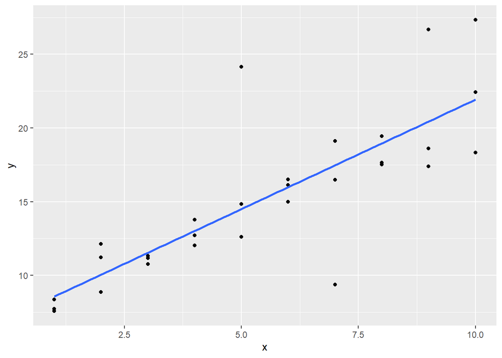

```r
sim1a <- tibble(
 x = rep(1:10, each = 3),
 y = x * 1.5 + 6 + rt(length(x), df = 2)
)

ggplot(sim1a, aes(x = x, y = y)) +
  geom_point() +
  geom_smooth(method = "lm", se = FALSE)
```

When running the ggplot function many times, I can see that the the slope and shape of the linear model does not really change, however, outliers do show up and the linear model can not account for them.

## Exercise 2

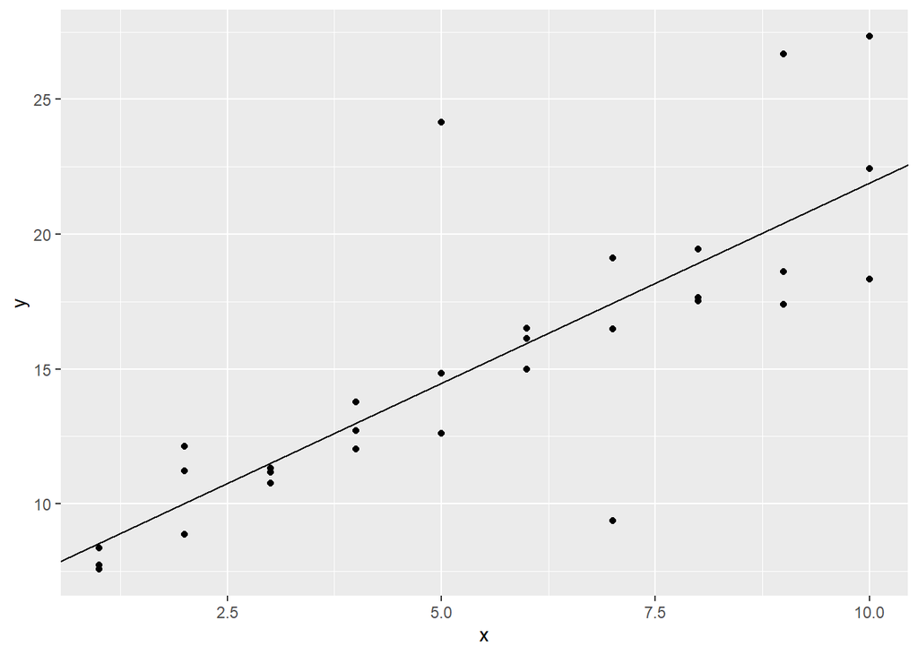

```r
measure_distance <- function(mod, data) {
 diff <- data$y - (mod[1] + mod[2] * data$x)
 sqrt(mean(diff^2))
}

better = optim(c(0,0), measure_distance, data = sim1a)
ggplot(sim1a, aes(x = x, y = y)) +
  geom_point() +
  geom_abline(intercept = better$par[1], slope = better$par[2])
```